# Abalone

Lab 1

Brendan Alexander

9/27/2019

# Import the data

```r
data <- read.table("abalone.data",sep = ",")
head(data)
names(data) <- c("sex","length","diameter", "height", "whole", "shucked", "viscera", "shell", "rings")
head(data)
# pairs(data)
```

[output not shown]

# Week 1

**Team lead presenting:** Madsen (grp 3)

## Proposal (1-3PM)

1. Height: Outlier issue
   - check for outliers
   - Pulled 2 outliers from height
2. Check pairs again

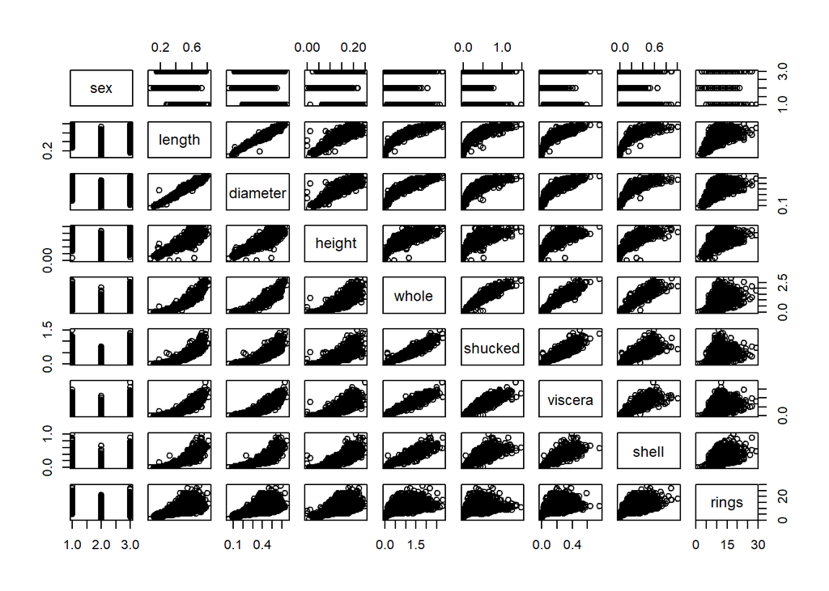

```r
data1 <- data[-c(2052,1418),]
pairs(data1)
```

Suggestions:

**Group 1**

- Stepwise regression to evaluate all the variables
- Remove outliers from weight
- Reconsider sex as: mature vs immature

**Group 2**

- Sex as a dummy variable?
- Don’t want to kill animals, stepwise regression,
  - How to estimate weights without killing?
  - Use whole weight, regress on shucked viscera and shell
    - derived variables from the weight

**Group 4**

- Correlations first, with `ring`
  - diameter has a strong correlation
  - combine length, diameter and height, make a derived variable

## Proposal

1. Inspect correlations
   - sex length and diameter highest correlation, no death
2. Box plots
   - comparative boxplots for the different sex categories
3. Outliers?
   - hov?
     - if not homogeneous, transform the data
4. fit a model
   - rings (or age) ~ (nothing specified)
5. Derived variable –> mature = male + female vs infant
   - boxPlot against length and diameter
6. Derived variable –> volume = length*diameter*height
7. Multiple regression: whole ~ shucked + viscera + shell

# Week 2: Fulfilling the proposal, collaborating with git

You all had several good initial analysis ideas. Unfortunately, your programmer was fired. You have to code it yourself.

Let’s break the problem down into the following components:

1. Data cleaning
   - Please removed the 2 outliers from the `height` variable and re-run the `pairs` plot.
2. Variable manipulation
   - Create a new variable “mature” based on “sex”
     - Male and female are mature, infants are not
   - Create a new variable “volume” based on “length”, “diameter”, and “height”
3. Visualize the data
   - Plot metrics by sex
4. Model fit: Can we predict shucked, viscera, and shell weight based on whole weight?
5. Model fit: Perform an initial model fit for “rings”.
   - You can use a `stepwise` procedure if you like.

Groups are the same as last time. Group leaders are now:

1. Yuting
2. Jenny
3. Fik
4. Allen

Group leaders are responsible for reporting their analysis.